# MPDW Praktikum Pertemuan 1

Nizar Hermawan (G1401231054)

2025-08-30

# Import Data

```r
library("forecast")
```

```r
library("ggplot2")
library("graphics")
library("TTR")
library("TSA")
#baca data "C:\Users\Nizar\Downloads\Documents\Data Cuaca Kelompok 2 MPDW.csv"
datacuaca <- read.csv("C:/Users/Nizar/Downloads/Documents/Data Cuaca Kelompok 2 MPDW.csv")
datacuaca
```

```
##                 date       p     T   Tpot  Tdew    rh VPmax VPact VPdef   sh
## 1      1/1/2020 0:10 1008.89  0.71 273.18 -1.33 86.10  6.43  5.54  0.89 3.42
## 2      1/1/2020 0:20 1008.76  0.75 273.22 -1.44 85.20  6.45  5.49  0.95 3.39
## 3      1/1/2020 0:30 1008.66  0.73 273.21 -1.48 85.10  6.44  5.48  0.96 3.39
## 4      1/1/2020 0:40 1008.64  0.37 272.86 -1.64 86.30  6.27  5.41  0.86 3.35
## 5      1/1/2020 0:50 1008.61  0.33 272.82 -1.50 87.40  6.26  5.47  0.79 3.38
## 6      1/1/2020 1:00 1008.44  0.34 272.84 -1.54 87.10  6.26  5.45  0.81 3.37
## 7      1/1/2020 1:10 1008.49  0.19 272.69 -1.65 87.40  6.19  5.41  0.78 3.34
## 8      1/1/2020 1:20 1008.40  0.03 272.53 -1.70 88.10  6.12  5.39  0.73 3.33
## 9      1/1/2020 1:30 1008.29  0.11 272.63 -1.61 88.10  6.16  5.43  0.73 3.35
## 10     1/1/2020 1:40 1008.28  0.22 272.73 -1.62 87.40  6.20  5.42  0.78 3.35
## 11     1/1/2020 1:50 1008.24 -0.04 272.48 -1.85 87.50  6.09  5.33  0.76 3.29
## 12     1/1/2020 2:00 1008.32 -0.21 272.30 -1.78 89.10  6.01  5.36  0.66 3.31
## 13     1/1/2020 2:10 1008.24 -0.10 272.42 -1.74 88.60  6.06  5.37  0.69 3.32
## 14     1/1/2020 2:20 1008.35 -0.16 272.35 -1.88 88.10  6.04  5.32  0.72 3.29
```

[output cut: 14272 more lines]

```r
datacuaca2 <- datacuaca[301:400, c("date", "VPdef")]
datacuaca2
```

```
##               date VPdef
## 301  1/3/2020 2:10  0.99
## 302  1/3/2020 2:20  0.93
## 303  1/3/2020 2:30  0.91
## 304  1/3/2020 2:40  0.88
## 305  1/3/2020 2:50  0.93
## 306  1/3/2020 3:00  0.92
## 307  1/3/2020 3:10  1.06
## 308  1/3/2020 3:20  1.10
## 309  1/3/2020 3:30  1.19
## 310  1/3/2020 3:40  1.22
## 311  1/3/2020 3:50  1.26
## 312  1/3/2020 4:00  1.26
## 313  1/3/2020 4:10  1.16
## 314  1/3/2020 4:20  1.15
```

[output cut: 86 more lines]

## ubah data VPdef menjadi time series

```r
data.ts <- ts(datacuaca2$VPdef)
```

# Ekspolrasi data

## Ringkasan data

```r
summary(data.ts)
```

```
##    Min. 1st Qu.  Median    Mean 3rd Qu.    Max.
##   0.880   1.157   1.405   1.597   2.155   2.680
```

## Plot data time series

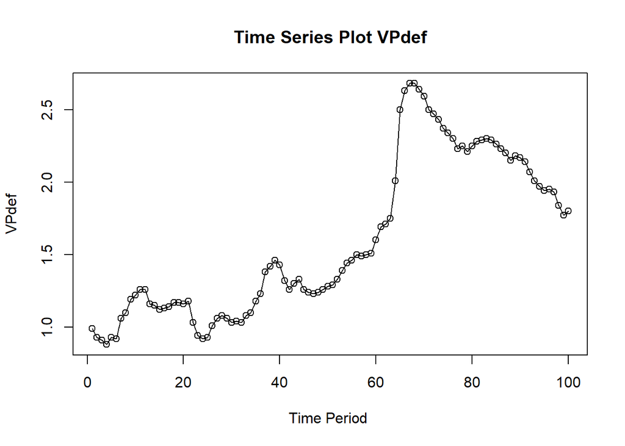

```r
ts.plot(data.ts, xlab="Time Period ", ylab="VPdef",
        main = "Time Series Plot VPdef")
points(data.ts)
```

# sma

```r
# Hitung jumlah baris data
n <- nrow(datacuaca2)

# Tentukan batas 80% untuk training
n_train <- floor(0.8 * n)

# Bagi data menjadi training dan testing
training_ma <- datacuaca2[1:n_train, ]
testing_ma  <- datacuaca2[(n_train+1):n, ]

# Ubah ke time series
train_ma.ts<- ts(training_ma$VPdef)
test_ma.ts <- ts(testing_ma$VPdef)
```

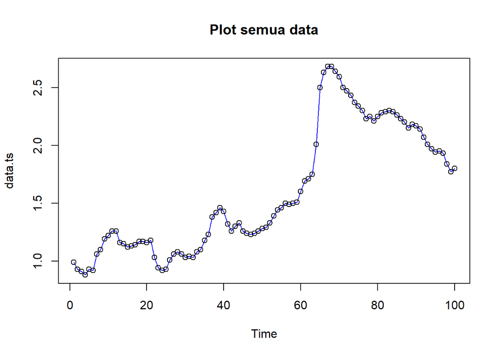

```r
#eksplorasi kesuluraan data
plot(data.ts, col="blue",main="Plot semua data")
points(data.ts)
```

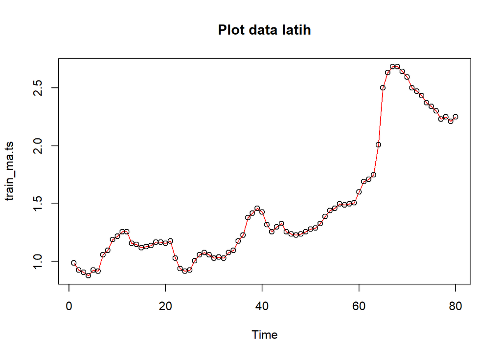

```r
#eksplorasi data latih
plot(train_ma.ts, col="red",main="Plot data latih")
points(train_ma.ts)
```

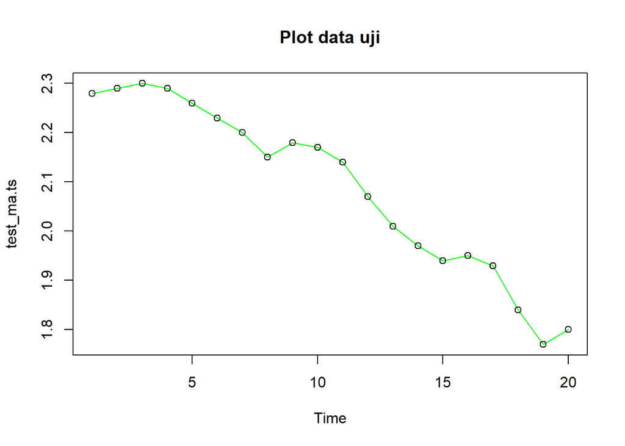

```r
#eksplorasi data uji
plot(test_ma.ts, col="green",main="Plot data uji")
points(test_ma.ts)
```

```r
data.sma<-SMA(train_ma.ts, n=4)
data.sma
```

```
## Time Series:
## Start = 1
## End = 80
## Frequency = 1
##  [1]     NA     NA     NA 0.9275 0.9125 0.9100 0.9475 1.0025 1.0675 1.1425
## [11] 1.1925 1.2325 1.2250 1.2075 1.1725 1.1400 1.1350 1.1400 1.1525 1.1600
## [21] 1.1700 1.1350 1.0775 1.0175 0.9550 0.9500 0.9800 1.0200 1.0525 1.0575
## [31] 1.0525 1.0400 1.0450 1.0625 1.0975 1.1475 1.2225 1.3025 1.3725 1.4225
## [41] 1.4075 1.3675 1.3275 1.3025 1.2875 1.2825 1.2650 1.2425 1.2425 1.2525
## [51] 1.2675 1.2900 1.3225 1.3625 1.4050 1.4475 1.4725 1.4875 1.5000 1.5250
## [61] 1.5750 1.6275 1.6875 1.7900 1.9925 2.2225 2.4550 2.6225 2.6575 2.6475
## [71] 2.6025 2.5500 2.4975 2.4425 2.4025 2.3600 2.3100 2.2800 2.2475 2.2350
```

Data pemulusan pada periode ke-t selanjutnya digunakan sebagai nilai peramalan pada periode ke t+1 sehingga hasil peramalan 1 periode kedepan adalah sebagai berikut.

```r
data.ramal<-c(NA,data.sma)
data.ramal #forecast 1 periode ke depan
```

```
##  [1]     NA     NA     NA     NA 0.9275 0.9125 0.9100 0.9475 1.0025 1.0675
## [11] 1.1425 1.1925 1.2325 1.2250 1.2075 1.1725 1.1400 1.1350 1.1400 1.1525
## [21] 1.1600 1.1700 1.1350 1.0775 1.0175 0.9550 0.9500 0.9800 1.0200 1.0525
## [31] 1.0575 1.0525 1.0400 1.0450 1.0625 1.0975 1.1475 1.2225 1.3025 1.3725
## [41] 1.4225 1.4075 1.3675 1.3275 1.3025 1.2875 1.2825 1.2650 1.2425 1.2425
## [51] 1.2525 1.2675 1.2900 1.3225 1.3625 1.4050 1.4475 1.4725 1.4875 1.5000
## [61] 1.5250 1.5750 1.6275 1.6875 1.7900 1.9925 2.2225 2.4550 2.6225 2.6575
## [71] 2.6475 2.6025 2.5500 2.4975 2.4425 2.4025 2.3600 2.3100 2.2800 2.2475
## [81] 2.2350
```

```r
data.gab<-cbind(
  aktual=c(data.ts),
  pemulusan=c(data.sma,rep(NA,24)),
  ramalan=c(data.ramal,rep(data.ramal[length(data.ramal)],23)))
data.gab #forecast 24 periode ke depan
```

```
##        aktual pemulusan ramalan
##   [1,]   0.99        NA      NA
##   [2,]   0.93        NA      NA
##   [3,]   0.91        NA      NA
##   [4,]   0.88    0.9275      NA
##   [5,]   0.93    0.9125  0.9275
##   [6,]   0.92    0.9100  0.9125
##   [7,]   1.06    0.9475  0.9100
##   [8,]   1.10    1.0025  0.9475
##   [9,]   1.19    1.0675  1.0025
##  [10,]   1.22    1.1425  1.0675
##  [11,]   1.26    1.1925  1.1425
##  [12,]   1.26    1.2325  1.1925
##  [13,]   1.16    1.2250  1.2325
##  [14,]   1.15    1.2075  1.2250
```

[output cut: 90 more lines]

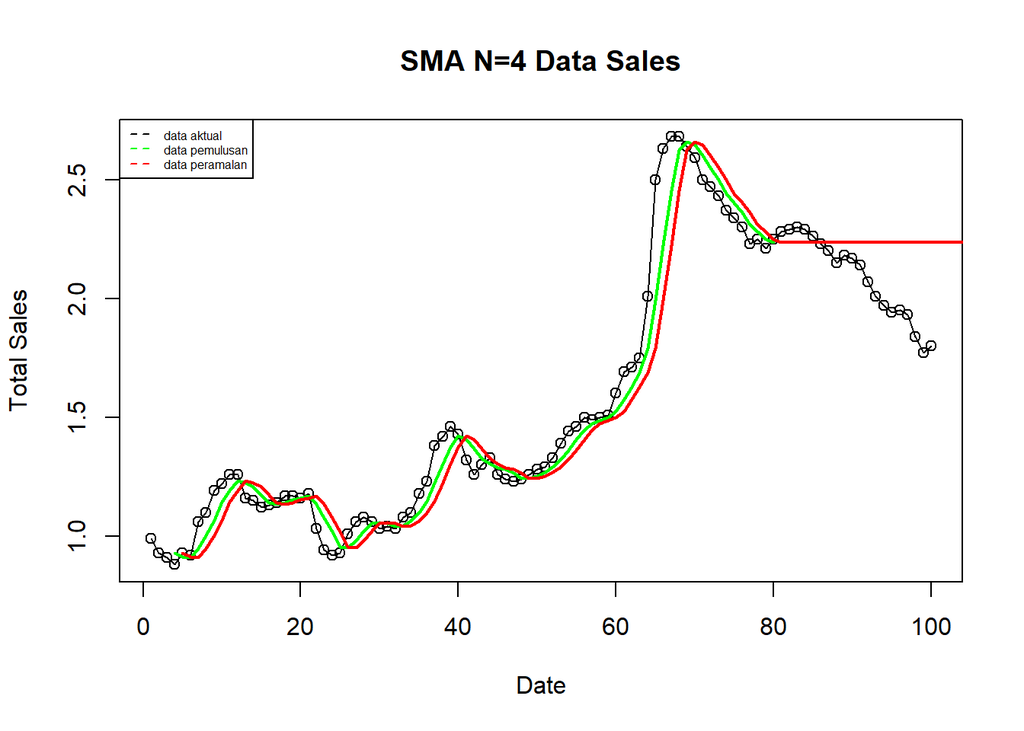

```r
ts.plot(data.ts, xlab="Date", ylab="Total Sales", main= "SMA N=4 Data Sales")
points(data.ts)
lines(data.gab[,2],col="green",lwd=2)
lines(data.gab[,3],col="red",lwd=2)
legend("topleft",c("data aktual","data pemulusan","data peramalan"), lty=8, col=c("black","green","red"), cex=0.5)
```

```r
#Menghitung nilai keakuratan data latih
error_train.sma = train_ma.ts-data.ramal[1:length(train_ma.ts)]

SSE_train.sma = sum(error_train.sma[5:length(train_ma.ts)]^2)
MSE_train.sma = mean(error_train.sma[5:length(train_ma.ts)]^2)
MAPE_train.sma = mean(abs((error_train.sma[5:length(train_ma.ts)]/train_ma.ts[5:length(train_ma.ts)])*100))

akurasi_train.sma <- matrix(c(SSE_train.sma, MSE_train.sma, MAPE_train.sma))
row.names(akurasi_train.sma)<- c("SSE", "MSE", "MAPE")
colnames(akurasi_train.sma) <- c("Akurasi m = 4")
akurasi_train.sma
```

```
##      Akurasi m = 4
## SSE     1.98366250
## MSE     0.02610082
## MAPE    6.97866495
```

```r
# Ambil data aktual (baris 81-104, kolom 1)
actual_test <- data.gab[81:104, 1]

# Ambil data ramalan (baris 81-104, kolom 3)
forecast_test <- data.gab[81:104, 3]

# Hitung error
error_test.sma <- actual_test - forecast_test

# Hitung metrik
SSE_test.sma <- sum(error_test.sma^2)
MSE_test.sma <- mean(error_test.sma^2)
MAPE_test.sma <- mean(abs(error_test.sma / actual_test * 100))

# Simpan dalam matrix
akurasi_test.sma <- matrix(c(SSE_test.sma, MSE_test.sma, MAPE_test.sma))
row.names(akurasi_test.sma) <- c("SSE", "MSE", "MAPE")
colnames(akurasi_test.sma) <- c("Akurasi m = 4")

akurasi_test.sma
```

```
##      Akurasi m = 4
## SSE      7.8532000
## MSE      0.3272167
## MAPE    30.9268425
```

## interpretasi sma

Training: MAPE 6.98% → cukup bagus Testing: MAPE melonjak jadi 30.93% → prediksi buruk, model kurang adaptif terhadap tren dan fluktuasi. Kesimpulan: Kurang cocok untuk data 10-menitan yang fluktuatif/trending.

# dma

```r
dma <- SMA(data.sma, n = 4)
At <- 2*data.sma - dma
Bt <- 2/(4-1)*(data.sma - dma)
data.dma<- At+Bt
data.ramal<- c(NA, data.dma)

t = 1:24
f = c()

for (i in t) {
  f[i] = At[length(At)] + Bt[length(Bt)]*(i)
}

data.gab2 <- cbind(aktual = c(data.ts),
                   pemulusan1 = c(data.sma,rep(NA,24)),
                   pemulusan2 = c(dma, rep(NA,24)),
                   At = c(At, rep(NA,24)),
                   Bt = c(Bt,rep(NA,24)),
                   ramalan = c(data.ramal, f[-1]))
data.gab2
```

```
##        aktual pemulusan1 pemulusan2       At           Bt   ramalan
##   [1,]   0.99         NA         NA       NA           NA        NA
##   [2,]   0.93         NA         NA       NA           NA        NA
##   [3,]   0.91         NA         NA       NA           NA        NA
##   [4,]   0.88     0.9275         NA       NA           NA        NA
##   [5,]   0.93     0.9125         NA       NA           NA        NA
##   [6,]   0.92     0.9100         NA       NA           NA        NA
##   [7,]   1.06     0.9475   0.924375 0.970625  0.015416667        NA
##   [8,]   1.10     1.0025   0.943125 1.061875  0.039583333 0.9860417
##   [9,]   1.19     1.0675   0.981875 1.153125  0.057083333 1.1014583
##  [10,]   1.22     1.1425   1.040000 1.245000  0.068333333 1.2102083
##  [11,]   1.26     1.1925   1.101250 1.283750  0.060833333 1.3133333
##  [12,]   1.26     1.2325   1.158750 1.306250  0.049166667 1.3445833
##  [13,]   1.16     1.2250   1.198125 1.251875  0.017916667 1.3554167
##  [14,]   1.15     1.2075   1.214375 1.200625 -0.004583333 1.2697917
```

[output cut: 90 more lines]

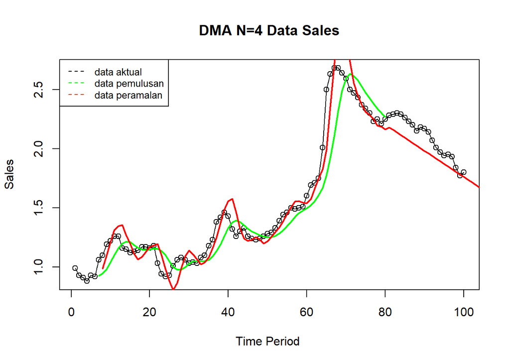

```r
ts.plot(data.ts, xlab="Time Period ", ylab="Sales", main= "DMA N=4 Data Sales")
points(data.ts)
lines(data.gab2[,3],col="green",lwd=2)
lines(data.gab2[,6],col="red",lwd=2)
legend("topleft",c("data aktual","data pemulusan","data peramalan"), lty=8, col=c("black","green","red"), cex=0.8)
```

```r
#Menghitung nilai keakuratan data latih
error_train.dma = train_ma.ts-data.ramal[1:length(train_ma.ts)]

SSE_train.dma = sum(error_train.dma[8:length(train_ma.ts)]^2)
MSE_train.dma = mean(error_train.dma[8:length(train_ma.ts)]^2)
MAPE_train.dma = mean(abs((error_train.dma[8:length(train_ma.ts)]/train_ma.ts[8:length(train_ma.ts)])*100))

akurasi_train.dma <- matrix(c(SSE_train.dma, MSE_train.dma, MAPE_train.dma))
row.names(akurasi_train.dma)<- c("SSE", "MSE", "MAPE")
colnames(akurasi_train.dma) <- c("Akurasi m = 4")
akurasi_train.dma
```

```
##      Akurasi m = 4
## SSE      1.4061187
## MSE      0.0192619
## MAPE     6.2533305
```

```r
n_test <- length(test_ma.ts)        # misal 24
error_test.dma <- test_ma.ts - data.gab2[(nrow(data.gab2)-n_test+1):nrow(data.gab2), 6]

SSE_test.dma <- sum(error_test.dma^2)
MSE_test.dma <- mean(error_test.dma^2)
MAPE_test.dma <- mean(abs(error_test.dma / test_ma.ts * 100))

akurasi_test.dma <- matrix(c(SSE_test.dma, MSE_test.dma, MAPE_test.dma))
row.names(akurasi_test.dma) <- c("SSE", "MSE", "MAPE")
colnames(akurasi_test.dma) <- c("Akurasi m = 4")
akurasi_test.dma
```

```
##      Akurasi m = 4
## SSE     0.91491267
## MSE     0.04574563
## MAPE    9.77885697
```

## interpretasi dma

Training: MAPE 6.25%, SSE lebih rendah dari SMA. Testing: MAPE 9.78% → masih lebih baik dari SMA, tapi belum optimal, karena mendekati 10% Kesimpulan: Lebih responsif dari SMA, tapi belum cukup untuk data dengan tren/jumlah fluktuasi tinggi.

# ses

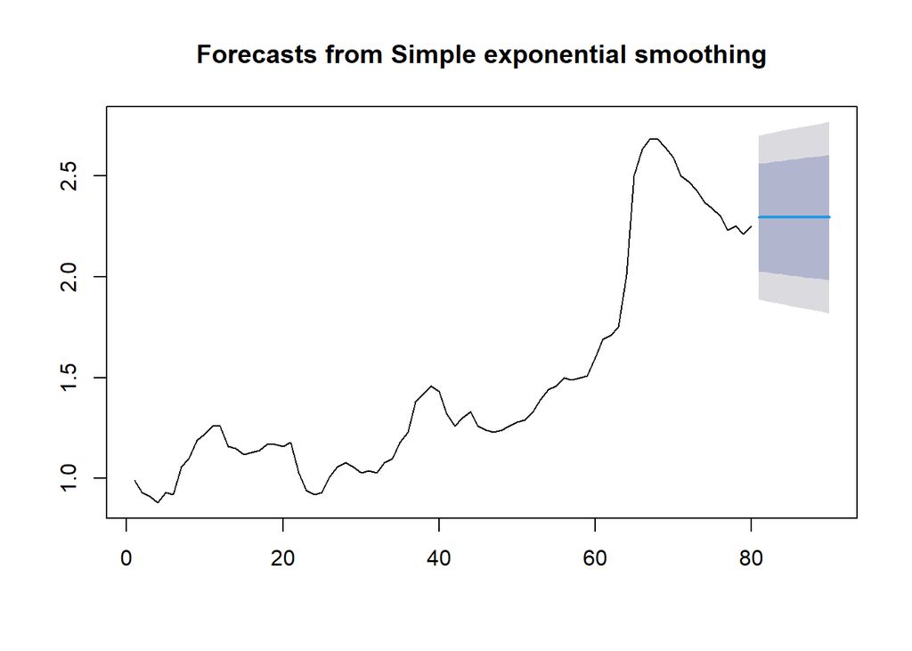

```r
# Ubah ke time series
train_ma.ts <- ts(training_ma$VPdef)
test_ma.ts  <- ts(testing_ma$VPdef)

#Cara 1 (fungsi ses)
ses.1 <- ses(train_ma.ts, h = 10, alpha = 0.2)
plot(ses.1)
```

```r
ses.1
```

```
##    Point Forecast    Lo 80    Hi 80    Lo 95    Hi 95
## 81       2.293111 2.027489 2.558734 1.886877 2.699346
## 82       2.293111 2.022228 2.563994 1.878832 2.707391
## 83       2.293111 2.017068 2.569154 1.870940 2.715283
## 84       2.293111 2.012003 2.574220 1.863193 2.723030
## 85       2.293111 2.007027 2.579196 1.855583 2.730639
## 86       2.293111 2.002136 2.584086 1.848104 2.738119
## 87       2.293111 1.997327 2.588896 1.840748 2.745475
## 88       2.293111 1.992594 2.593629 1.833509 2.752713
## 89       2.293111 1.987934 2.598288 1.826383 2.759839
## 90       2.293111 1.983345 2.602878 1.819364 2.766858
```

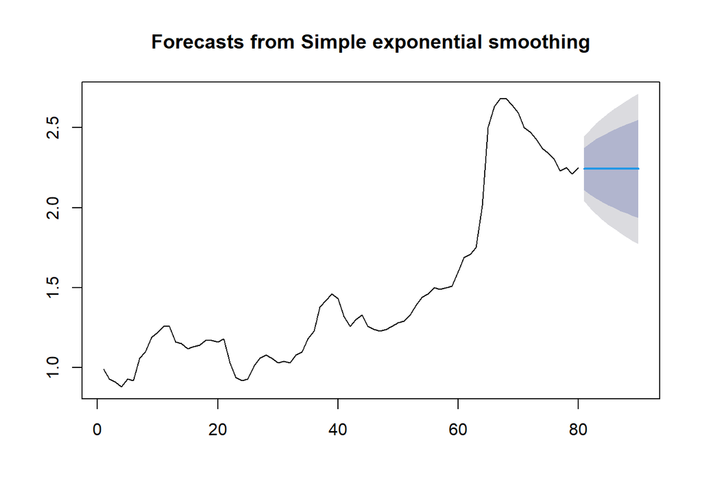

```r
ses.2<- ses(train_ma.ts, h = 10, alpha = 0.7)
plot(ses.2)
```

```r
ses.2
```

```
##    Point Forecast    Lo 80    Hi 80    Lo 95    Hi 95
## 81       2.241763 2.109907 2.373619 2.040106 2.443420
## 82       2.241763 2.080812 2.402714 1.995610 2.487916
## 83       2.241763 2.056225 2.427301 1.958007 2.525519
## 84       2.241763 2.034535 2.448991 1.924835 2.558691
## 85       2.241763 2.014909 2.468617 1.894820 2.588706
## 86       2.241763 1.996851 2.486675 1.867203 2.616323
## 87       2.241763 1.980036 2.503490 1.841486 2.642040
## 88       2.241763 1.964238 2.519288 1.817325 2.666201
## 89       2.241763 1.949292 2.534234 1.794467 2.689059
## 90       2.241763 1.935073 2.548453 1.772722 2.710804
```

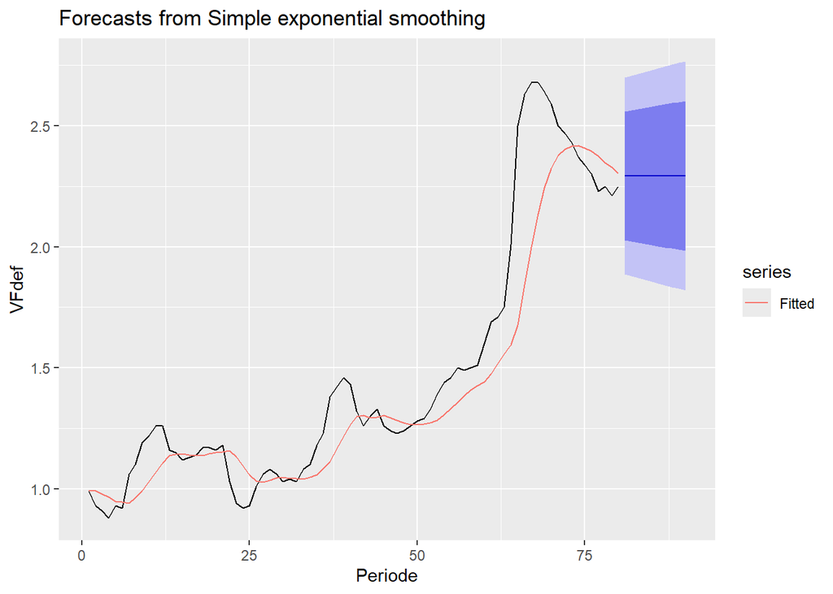

```r
autoplot(ses.1) +
  autolayer(fitted(ses.1), series="Fitted") +
  ylab("VFdef") + xlab("Periode")
```

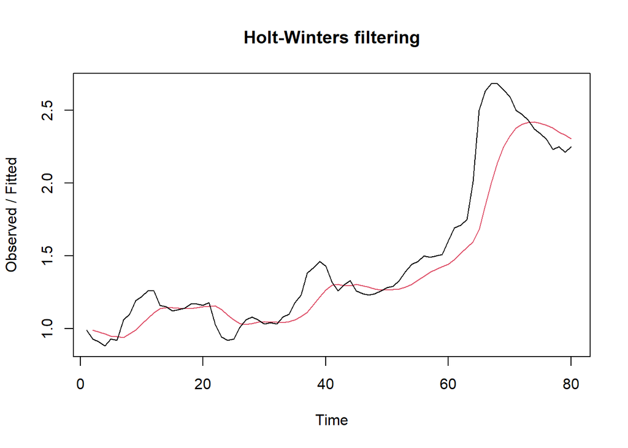

```r
#Cara 2 (fungsi Holtwinter)
ses1<- HoltWinters(train_ma.ts, gamma = FALSE, beta = FALSE, alpha = 0.2)
plot(ses1)
```

```r
#ramalan
ramalan1<- forecast(ses1, h=10)
ramalan1
```

```
##    Point Forecast    Lo 80    Hi 80    Lo 95    Hi 95
## 81       2.293111 2.049718 2.536505 1.920873 2.665350
## 82       2.293111 2.044898 2.541325 1.913501 2.672721
## 83       2.293111 2.040169 2.546053 1.906270 2.679953
## 84       2.293111 2.035528 2.550695 1.899171 2.687051
## 85       2.293111 2.030968 2.555254 1.892198 2.694024
## 86       2.293111 2.026487 2.559736 1.885345 2.700878
## 87       2.293111 2.022080 2.564143 1.878604 2.707618
## 88       2.293111 2.017743 2.568480 1.871972 2.714251
## 89       2.293111 2.013473 2.572749 1.865442 2.720781
## 90       2.293111 2.009268 2.576954 1.859011 2.727212
```

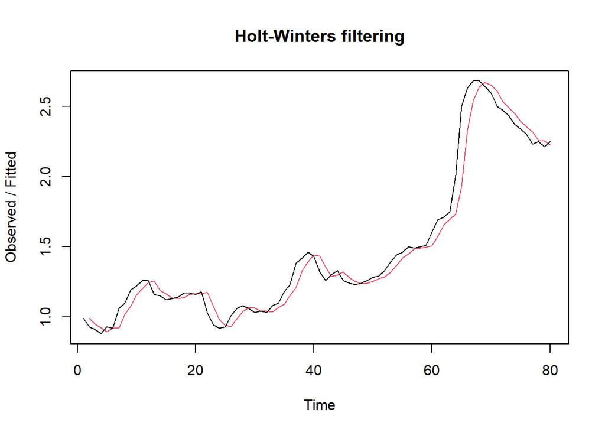

```r
ses2<- HoltWinters(train_ma.ts, gamma = FALSE, beta = FALSE, alpha = 0.7)
plot(ses2)
```

```r
#ramalan
ramalan2<- forecast(ses2, h=10)
ramalan2
```

```
##    Point Forecast    Lo 80    Hi 80    Lo 95    Hi 95
## 81       2.241763 2.113143 2.370383 2.045056 2.438470
## 82       2.241763 2.084762 2.398764 2.001651 2.481875
## 83       2.241763 2.060779 2.422747 1.964971 2.518555
## 84       2.241763 2.039621 2.443905 1.932613 2.550913
## 85       2.241763 2.020477 2.463049 1.903335 2.580191
## 86       2.241763 2.002862 2.480664 1.876396 2.607130
## 87       2.241763 1.986460 2.497066 1.851310 2.632216
## 88       2.241763 1.971049 2.512477 1.827742 2.655784
## 89       2.241763 1.956470 2.527056 1.805445 2.678081
## 90       2.241763 1.942601 2.540925 1.784234 2.699292
```

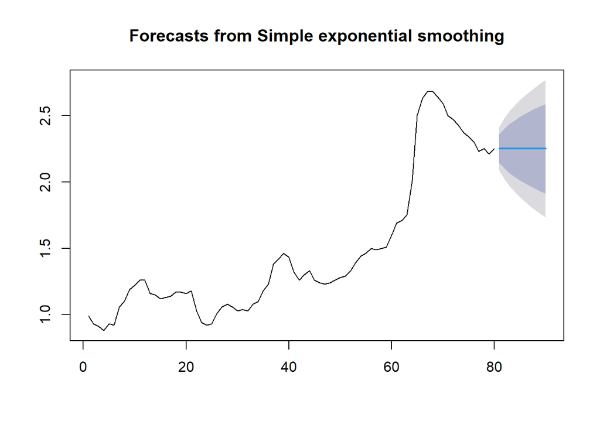

```r
#SES
ses.opt <- ses(train_ma.ts, h = 10, alpha = NULL)
plot(ses.opt)
```